# Ford GoBike Bay Wheels Data Exploration

## by Kimberley Moore

### Investigation Overview

In this investigation, I want to look at the relationship between the different groups (age, gender and user type) and popular biking times(time of the month, day of the week and hour of the day).

### Dataset Overview

This project explores a dataset containing Bay Wheels's bike trip data for 2018. The data consists of information for 1,863,721 bike trips, including duration, start time, end time, user type, member birth year, member gender and other bike trip features.

## Univariate Exploration

I'll start by looking at the different categorical data types

First we'll start with Member Gender

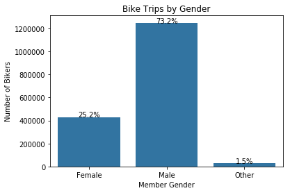

```python
# create the plot
sb.countplot(data = fordbike_2018_clean, x = 'member_gender', color = base_color)
plt.title("Bike Trips by Gender")
plt.xlabel("Member Gender")
plt.ylabel("Number of Bikers")

# add annotations
n_points = fordbike_2018_clean.shape[0]
cat_counts = fordbike_2018_clean['member_gender'].value_counts()
locs, labels = plt.xticks() # get the current tick locations and labels

# loop through each pair of locations and labels
for loc, label in zip(locs, labels):

    # get the text property for the label to get the correct count
    count = cat_counts[label.get_text()]
    pct_string = '{:0.1f}%'.format(100*count/n_points)

    # print the annotation just below the top of the bar
    plt.text(loc, count-8, pct_string, ha = 'center', color = 'k');
```

73.2 % of bikers are Male, 25.2% of bikers are Female and 1.5% of bikers are categrized as Other

Next, let's take a look at the member ages groups

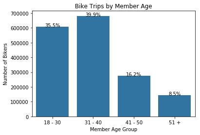

```python
level_order = ['18 - 30', '31 - 40', '41 - 50', '51 +']
ordered_cat = pd.api.types.CategoricalDtype(ordered = True, categories = level_order)
fordbike_2018_clean['member_age_group'] = fordbike_2018_clean['member_age_group'].astype(ordered_cat)

# create the plot
sb.countplot(data = fordbike_2018_clean, x = 'member_age_group', color = base_color)
plt.title("Bike Trips by Member Age")
plt.xlabel("Member Age Group")
plt.ylabel("Number of Bikers")

# add annotations
n_points = fordbike_2018_clean.shape[0]
cat_counts = fordbike_2018_clean['member_age_group'].value_counts()
locs, labels = plt.xticks() # get the current tick locations and labels

# loop through each pair of locations and labels
for loc, label in zip(locs, labels):

    # get the text property for the label to get the correct count
    count = cat_counts[label.get_text()]
    pct_string = '{:0.1f}%'.format(100*count/n_points)

    # print the annotation just below the top of the bar
    plt.text(loc, count-8, pct_string, ha = 'center', color = 'k');
```

Majority of the members are between the ages 31-40

Next we'll look at Bike Trips by Month

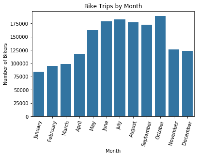

```python
# covert start_time_month to an ordered categorical type
level_order = ['January', 'February', 'March', 'April', 'May', 'June', 'July', 'August', 'September', 'October', 'November', 'December']
ordered_cat = pd.api.types.CategoricalDtype(ordered = True, categories = level_order)
fordbike_2018_clean['start_time_month'] = fordbike_2018_clean['start_time_month'].astype(ordered_cat)

sb.countplot(data = fordbike_2018_clean, x = 'start_time_month', color = base_color)
plt.title("Bike Trips by Month")
plt.xlabel("Month")
plt.ylabel("Number of Bikers")
plt.xticks(rotation = 75);
```

October has the most bike trips in 2018 while January has the least

Next we'll look at Bike Trips by Day of the Week

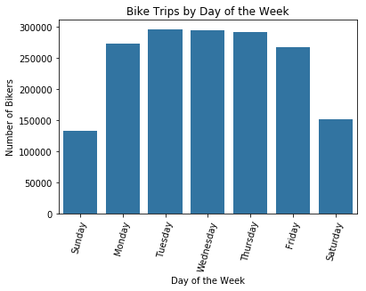

```python
# covert start_time_dayofweek to an ordered categorical type
level_order = ['Sunday', 'Monday', 'Tuesday', 'Wednesday', 'Thursday', 'Friday', 'Saturday']
ordered_cat = pd.api.types.CategoricalDtype(ordered = True, categories = level_order)
fordbike_2018_clean['start_time_dayofweek'] = fordbike_2018_clean['start_time_dayofweek'].astype(ordered_cat)

sb.countplot(data = fordbike_2018_clean, x = 'start_time_dayofweek', color = base_color)
plt.title("Bike Trips by Day of the Week")
plt.xlabel("Day of the Week")
plt.ylabel("Number of Bikers")
plt.xticks(rotation = 75);
```

Tuesdays have the most bike trips while Sundays and Saturdays have the least. This is interesting because I thought the weekends would have more trips since people have more time in the days for leisure. Perhaps bikers are using the service for commuting purposes.

Next we'll look at Bike Trips by Hour of the Day

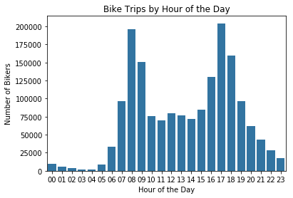

```python
# covert start_time_dayofweek to an ordered categorical type
'''
level_order = ['00', '01', '02', '03', '04', '05', '06', '07', '08', '09', '10', '11', '12', '13', '14', '15', '16',
              '17', '18', '19', '20', '21', '22', '23']
ordered_cat = pd.api.types.CategoricalDtype(ordered = True, categories = level_order)
fordbike_2018_clean['start_time_hour'] = fordbike_2018_clean['start_time_hour'].astype(ordered_cat)
'''

sb.countplot(data = fordbike_2018_clean, x = 'start_time_hour', color = base_color)
plt.title("Bike Trips by Hour of the Day")
plt.xlabel("Hour of the Day")
plt.ylabel("Number of Bikers");
```

We can see there are two peak hours 8 and 17 (8:00 AM and 5:00 PM). This supports the previous observation that bikers are using the service for commuting.

And finally let's look at the distribution of bike trip duration

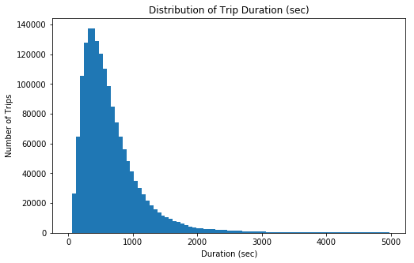

```python
binsize = 60
bin_edges = np.arange(0, fordbike_2018_clean['duration_sec'].max(), binsize)

plt.figure(figsize=[8, 5])
plt.hist(data = fordbike_2018_clean, x = 'duration_sec', bins = bin_edges)
plt.title("Distribution of Trip Duration (sec)")
plt.xlabel("Duration (sec)")
plt.ylabel("Number of Trips");
```

From this histgram, we can see that the histogram is right-skewed and majority of the trips are about 500 seconds long (approximately 8 minutes).

## Bivariate Exploration

Since majority of the bikers are male and seem to be between at 18-40. Let's plot that.

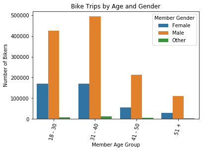

```python
ax = sb.countplot(data = fordbike_2018_clean, x = 'member_age_group', hue = 'member_gender')
ax.legend(title = 'Member Gender')
plt.title("Bike Trips by Age and Gender")
plt.xlabel("Member Age Group")
plt.ylabel("Number of Bikers")
plt.xticks(rotation = 75);
```

The plot above confirms that majority of bikers are Male between the age of 31-40

Let's first look at the Gender and Start Month

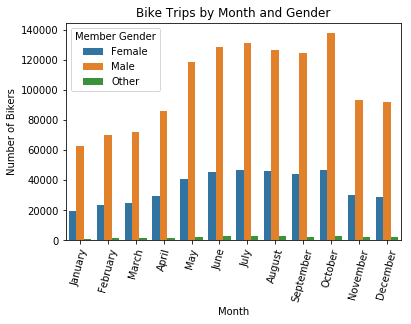

```python
ax = sb.countplot(data = fordbike_2018_clean, x = 'start_time_month', hue = 'member_gender')
ax.legend(title = 'Member Gender')
plt.title("Bike Trips by Month and Gender")
plt.xlabel("Month")
plt.ylabel("Number of Bikers")
plt.xticks(rotation = 75);
```

The trend seems to be consistent for both Male and Female gender across the months. However, more Males bike in October, while Females bike in most in July and October.

Next, let's look at Gender and Start Day of the Week

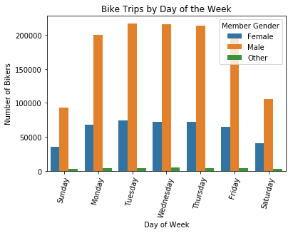

```python
ax = sb.countplot(data = fordbike_2018_clean, x = 'start_time_dayofweek', hue = 'member_gender')
ax.legend(title = 'Member Gender')
plt.title("Bike Trips by Day of the Week")
plt.xlabel("Day of Week")
plt.ylabel("Number of Bikers")
plt.xticks(rotation = 75);
```

The trend seems to be consistent for both Male and Female gender across the days of the week. So it doesn't seem like gender has any efefct on the day of the week that bikers ride.

Next, let's look at Gender and Start Hour

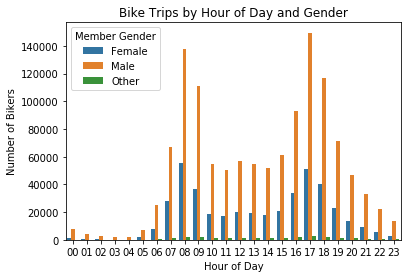

```python
ax = sb.countplot(data = fordbike_2018_clean, x = 'start_time_hour', hue = 'member_gender')
ax.legend(title = 'Member Gender')
plt.title("Bike Trips by Hour of Day and Gender")
plt.xlabel("Hour of Day")
plt.ylabel("Number of Bikers")
plt.figure(figsize=[10, 5]);
```

Both Male and Female genders have bimodal hours hours 8 and 17 (8:00 AM and 5:00 PM). Gender doesn't seem to have effect most frequent on hour of day.

Finally, let's look at Gender and Trip Duration

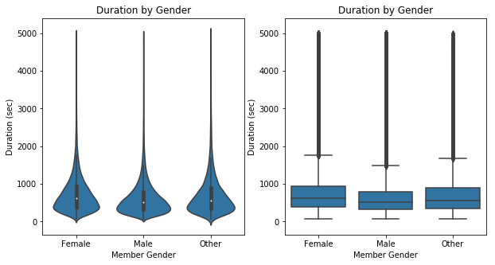

```python
plt.figure(figsize = [10, 5])

# left plot: violin plot
plt.subplot(1, 2, 1)
ax1 = sb.violinplot(data = fordbike_2018_clean, x = 'member_gender', y = 'duration_sec', color = base_color)
plt.title("Duration by Gender")
plt.xlabel("Member Gender")
plt.ylabel("Duration (sec)")

# right plot: box plot
plt.subplot(1, 2, 2)
sb.boxplot(data = fordbike_2018_clean, x = 'member_gender', y = 'duration_sec', color = base_color)
plt.title("Duration by Gender")
plt.xlabel("Member Gender")
plt.ylabel("Duration (sec)")

plt.ylim(ax1.get_ylim());
```

We can see females tend to have longer trip durations than Males

Now, let's first look at the Age Group and Month

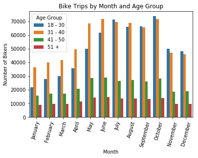

```python
ax = sb.countplot(data = fordbike_2018_clean, x = 'start_time_month', hue = 'member_age_group')
ax.legend(title = 'Age Group')
plt.title("Bike Trips by Month and Age Group")
plt.xlabel("Month")
plt.ylabel("Number of Bikers")
plt.xticks(rotation = 75)
plt.figure(figsize=[30, 20]);
```

Now, let's first look at the Age Group and Day of the week

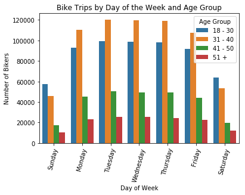

```python
ax = sb.countplot(data = fordbike_2018_clean, x = 'start_time_dayofweek', hue = 'member_age_group')
ax.legend(title = 'Age Group')
plt.title("Bike Trips by Day of the Week and Age Group")
plt.xlabel("Day of Week")
plt.ylabel("Number of Bikers")
plt.xticks(rotation = 75)
plt.figure(figsize=[30, 20]);
```

We can still see that most bikers bike on Tuesday. However, during the week, most bikers range between age 31-40, while on the weekends most bikers range between ages 18-30.

Now, let's first look at the Age Group and Hour of Day

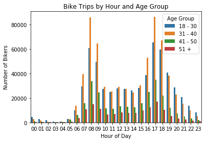

```python
ax = sb.countplot(data = fordbike_2018_clean, x = 'start_time_hour', hue = 'member_age_group')
ax.legend(title = 'Age Group')
plt.title("Bike Trips by Hour and Age Group")
plt.xlabel("Hour of Day")
plt.ylabel("Number of Bikers")
plt.figure(figsize=[50, 30]);
```

We still have bimodal hours hours 8 and 17 (8:00 AM and 5:00 PM) for all age groups. However, we can see the age group 18-30 bike more than other age groups during really early and really late hours (before 5:00 AM and after 7:00 PM)

Now, let's first look at the Age Group and Trip Duration

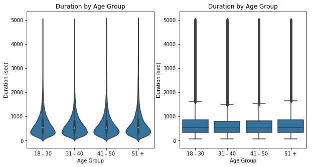

```python
plt.figure(figsize = [10, 5])

# left plot: violin plot
plt.subplot(1, 2, 1)
ax1 = sb.violinplot(data = fordbike_2018_clean, x = 'member_age_group', y = 'duration_sec', color = base_color)
plt.title("Duration by Age Group")
plt.xlabel("Age Group")
plt.ylabel("Duration (sec)")

# right plot: box plot
plt.subplot(1, 2, 2)
sb.boxplot(data = fordbike_2018_clean, x = 'member_age_group', y = 'duration_sec', color = base_color)
plt.title("Duration by Age Group")
plt.xlabel("Age Group")
plt.ylabel("Duration (sec)")
plt.ylim(ax1.get_ylim());
```

Age groups 18-30 and 51+ have a slight longer trip duration time but it doesn't seem strongly suggest that age group affects trip duration.

## Multivariate Exploration

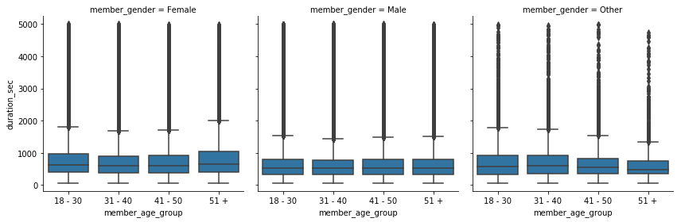

```python
g = sb.FacetGrid(data = fordbike_2018_clean, col = 'member_gender', size = 4)
g.map(sb.boxplot, 'member_age_group', 'duration_sec')
```

There is not much variation in the Female age groups to Male age groups